# Machine Learning with TensorFlow and R

## Overview

- TensorFlow Basics
- R Interfaces to TensorFlow
- Deep Learning
- Supporting Tools
- Case Studies
- Deployment
- Learning More

## What is TensorFlow?

### *A general purpose numerical computing library*

- Hardware independent
  - CPU (via C++ library [Eigen](http://eigen.tuxfamily.org/))
  - GPU (via CUDA)
  - TPU ([Tenor Processing Unit](https://en.wikipedia.org/wiki/Tensor_processing_unit))
  - Others…
- Supports distributed execution and very large datasets
- Supports [automatic differentiation](https://en.wikipedia.org/wiki/Automatic_differentiation)

## What are tensors?

### *Data stored in multidimensional arrays*

| Dimension | R object |
| --- | --- |
| 0D | `42` |
| 1D | `c(42, 42, 42)` |
| 2D | `matrix(42, nrow = 2, ncol = 2)` |
| 3D | `array(42, dim = c(2,3,2))` |
| 4D | `array(42, dim = c(2,3,2,3))` |

## Some examples

- *Vector data*—2D tensors of shape `(samples, features)`
- *Timeseries or sequence data*—3D tensors of shape `(samples, timesteps, features)`
- *Images*—4D tensors of shape `(samples, height, width, channels)`
- *Video*—5D tensors of shape `(samples, frames, height, width, channels)`

## 2D Tensors

### *Vector data*

```r
head(data.matrix(iris), n = 10)
```

```
      Sepal.Length Sepal.Width Petal.Length Petal.Width Species
 [1,]          5.1         3.5          1.4         0.2       1
 [2,]          4.9         3.0          1.4         0.2       1
 [3,]          4.7         3.2          1.3         0.2       1
 [4,]          4.6         3.1          1.5         0.2       1
 [5,]          5.0         3.6          1.4         0.2       1
 [6,]          5.4         3.9          1.7         0.4       1
 [7,]          4.6         3.4          1.4         0.3       1
 [8,]          5.0         3.4          1.5         0.2       1
 [9,]          4.4         2.9          1.4         0.2       1
[10,]          4.9         3.1          1.5         0.1       1
```

## 3D Tensors

### *Timeseries or sequence data*

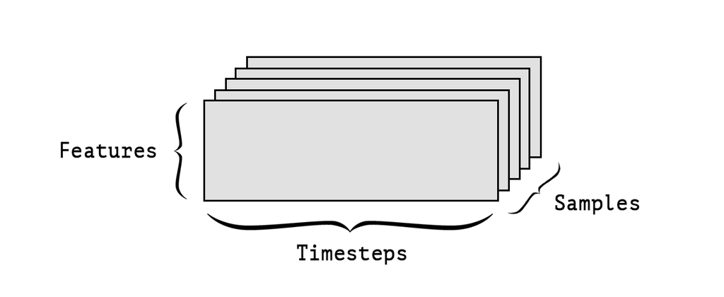

## 4D Tensors

### *Image data*

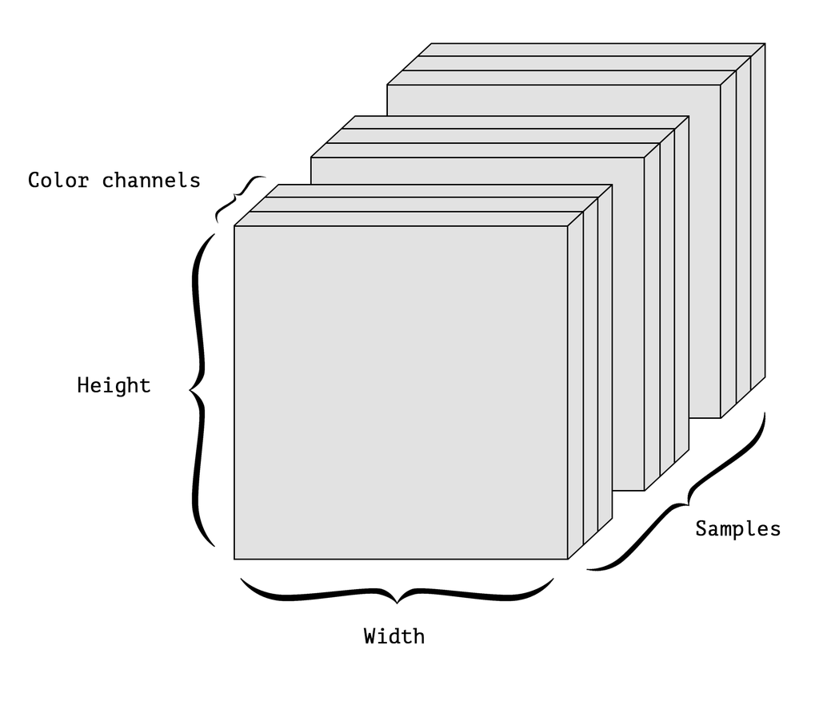

## What is tensor "flow"?

### A dataflow graph with nodes representing units of computation

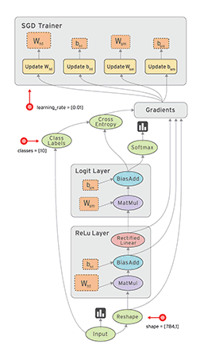

- **Parallelism**–System identifies operations that can execute in parallel.
- **Distributed execution**–Graph can be partitioned accross multiple devices.
- **Compilation**–Use the information in your dataflow graph to generate faster code (e.g. fusing operations)
- **Portability**–Dataflow graph is a language-independent representation of the code in your model (deploy with C++ runtime)

## Why should R users care about TensorFlow?

- A new general purpose numerical computing library with many potential applications!
- Models created with TensorFlow can be deployed with a low-latency C++ runtime
- Robust foundation for many deep learning applications
- R has a lot to offer as an *interface language* for TensorFlow

## Example: Greta

### Writing statistical models and fitting them by MCMC

[figure not shown]

https://greta-dev.github.io/greta/

## R Interface to Tensorflow

- High-level R interfaces for neural nets and traditional models
- Low-level interface to allow enable new applications (e.g. Greta)
- Tools to faciliate productive workflow / experiment management
- Easy access to GPUs for training models
- Breadth and depth of educational resources

## R Packages

| Package | Description |
| --- | --- |
| [keras](https://tensorflow.rstudio.com/keras/) | Interface for neural networks, with a focus on enabling fast experimentation. |
| [tfestimators](https://tensorflow.rstudio.com/tfestimators/) | Implementations of common model types such as regressors and classifiers. |
| [tensorflow](https://tensorflow.rstudio.com/tensorflow/) | Low-level interface to the TensorFlow computational graph. |
| [tfdatasets](https://tensorflow.rstudio.com/tools/tfdatasets/) | Scalable input pipelines for TensorFlow models. |
| [tfruns](https://tensorflow.rstudio.com/tools/tfruns/) | Track, visualize, and manage TensorFlow training runs and experiments. |
| [tfdeploy](https://tensorflow.rstudio.com/tools/tfdeploy/) | Tools designed to make exporting and serving TensorFlow models straightforward. |
| [cloudml](https://tensorflow.rstudio.com/tools/cloudml/) | R interface to Google Cloud Machine Learning Engine. |

[figure not shown]

- High-level neural networks API capable of running on top of [TensorFlow](https://www.tensorflow.org), [CNTK](https://www.microsoft.com/en-us/cognitive-toolkit/), or [Theano](http://www.deeplearning.net/software/theano/) (and soon [MXNet](https://mxnet.apache.org/)).
- Allows for easy and fast prototyping (through user friendliness, modularity, and extensibility).
- Supports both convolutional networks and recurrent networks, as well as combinations of the two.
- Runs seamlessly on CPU and GPU.
- https://keras.rstudio.com

## Keras Adoption

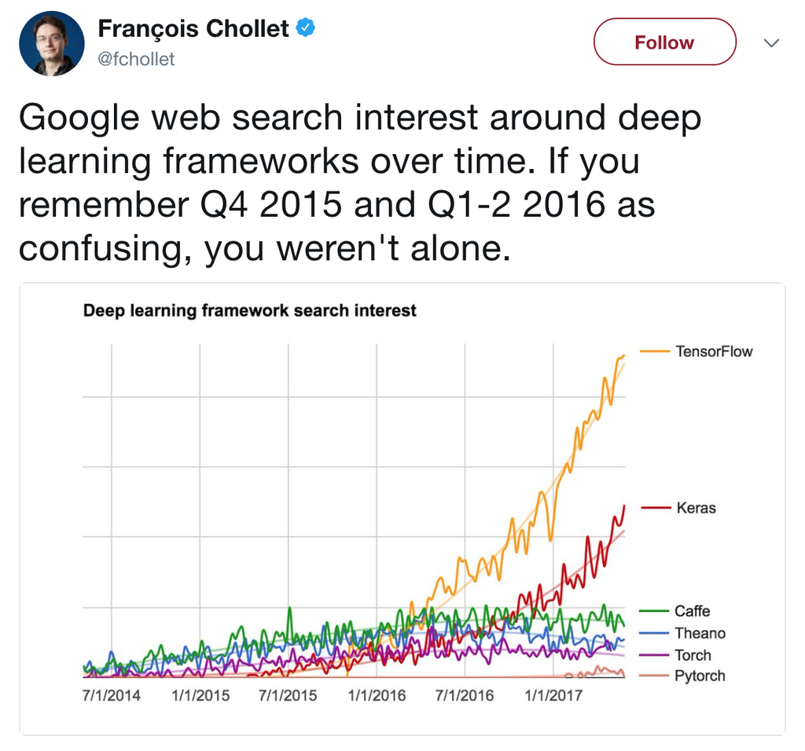

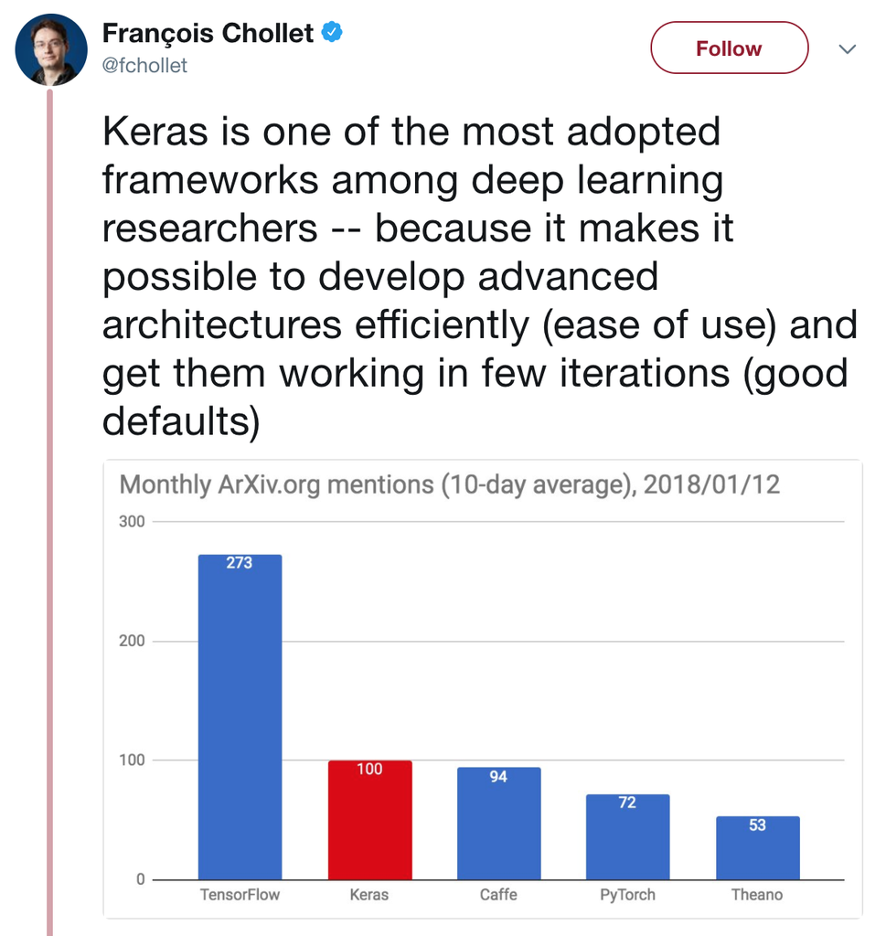

## First Look at Keras

### Training a simple multi-layer perceptron (MLP)

```r
library(keras)

model <- keras_model_sequential() %>%
  layer_dense(units = 32, activation = 'relu', input_shape = c(100)) %>%
  layer_dropout(rate = 0.2) %>%
  layer_dense(units = 16, activation = 'relu') %>%
  layer_dense(units = 1, activation = 'sigmoid')

model %>% compile(
  optimizer = 'rmsprop',
  loss = 'binary_crossentropy',
  metrics = c('accuracy')
)

model %>% fit(
  x = data, y = labels,
  epochs = 10,
  batch_size = 32
)
```

## Keras Layers

### Operations that are chained together to progressively distill data

```r
model <- keras_model_sequential() %>%
  layer_conv_2d(filters = 32, kernel_size = c(3,3), activation = 'relu',
                input_shape = input_shape) %>%
  layer_conv_2d(filters = 64, kernel_size = c(3,3), activation = 'relu') %>%
  layer_max_pooling_2d(pool_size = c(2, 2)) %>%
  layer_dropout(rate = 0.25) %>%
  layer_flatten() %>%
  layer_dense(units = 128, activation = 'relu') %>%
  layer_dropout(rate = 0.5) %>%
  layer_dense(units = num_classes, activation = 'softmax')
```

## In Place Modification

### Object semantics are not by-value! (as is conventional in R)

```r
# Modify model object in place (note that it is not assigned back to)
model %>% compile(
  optimizer = 'rmsprop',
  loss = 'binary_crossentropy',
  metrics = c('accuracy')
)
```

- Keras models are directed acyclic graphs of layers whose state is updated during training.
- Keras layers can be shared by mutliple parts of a Keras model.

## Keras Workflow – Data Preprocessing

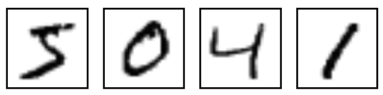

```r
library(keras)

# Load MNIST images datasets (built in to Keras)
c(c(x_train, y_train), c(x_test, y_test)) %<-% dataset_mnist()

# Flatten images and transform RGB values into [0,1] range
x_train <- array_reshape(x_train, c(nrow(x_train), 784))
x_test <- array_reshape(x_test, c(nrow(x_test), 784))
x_train <- x_train / 255
x_test <- x_test / 255

# Convert class vectors to binary class matrices
y_train <- to_categorical(y_train, 10)
y_test <- to_categorical(y_test, 10)
```

## Keras Workflow – Define Model

```r
model <- keras_model_sequential()  %>%
  layer_dense(units = 256, activation = 'relu', input_shape = c(784)) %>%
  layer_dropout(rate = 0.4) %>%
  layer_dense(units = 128, activation = 'relu') %>%
  layer_dropout(rate = 0.3) %>%
  layer_dense(units = 10, activation = 'softmax')

model %>% compile(
  loss = 'categorical_crossentropy',
  optimizer = optimizer_rmsprop(),
  metrics = c('accuracy')
)
```

## Keras Workflow – Define Model (cont.)

```r
summary(model)
```

```
_____________________________________________________________________________________
Layer (type)                          Output Shape                      Param #
=====================================================================================
dense_1 (Dense)                       (None, 256)                       200960
_____________________________________________________________________________________
dropout_1 (Dropout)                   (None, 256)                       0
_____________________________________________________________________________________
dense_2 (Dense)                       (None, 128)                       32896
_____________________________________________________________________________________
dropout_2 (Dropout)                   (None, 128)                       0
_____________________________________________________________________________________
dense_3 (Dense)                       (None, 10)                        1290
=====================================================================================
Total params: 235,146
Trainable params: 235,146
Non-trainable params: 0
_____________________________________________________________________________________
```

## Keras Workflow – Training

```r
history <- model %>% fit(
  x_train, y_train,
  batch_size = 128,
  epochs = 30,
  validation_split = 0.2
)
```

```r
history
```

[output not shown]

## Keras Workflow – Training (cont.)

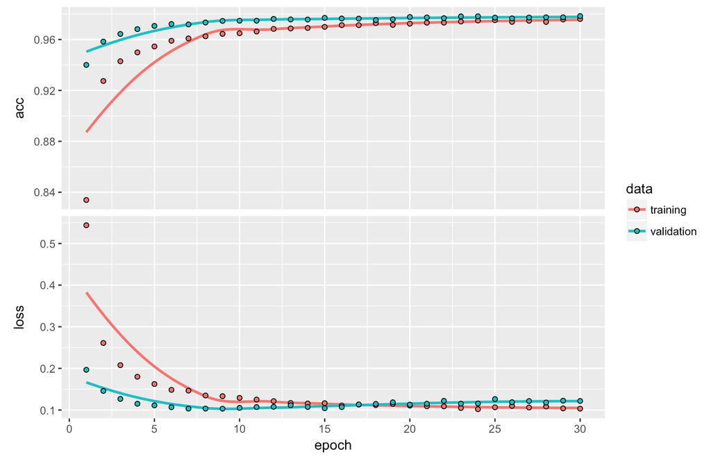

```r
plot(history)
```

## Keras Workflow – Evaluation and Prediction

```r
model %>% evaluate(x_test, y_test)
```

```
$loss
[1] 0.1078904

$acc
[1] 0.9815
```

```r
model %>% predict_classes(x_test[1:100,])
```

```
  [1] 7 2 1 0 4 1 4 9 5 9 0 6 9 0 1 5 9 7 3 4 9 6 6 5 4 0 7 4 0 1 3 1 3 4 7
 [36] 2 7 1 2 1 1 7 4 2 3 5 1 2 4 4 6 3 5 5 6 0 4 1 9 5 7 8 9 3 7 4 6 4 3 0
 [71] 7 0 2 9 1 7 3 2 9 7 7 6 2 7 8 4 7 3 6 1 3 6 9 3 1 4 1 7 6 9
```

## TensorFlow Estimators

### High level API for TensorFlow models https://tensorflow.rstudio.com/tfestimators/

| Estimator | Description |
| --- | --- |
| linear_regressor() | Linear regressor model. |
| linear_classifier() | Linear classifier model. |
| dnn_regressor() | Dynamic nueral network regression. |
| dnn_classifier() | Dynamic nueral network classification. |
| dnn_linear_combined_regressor() | DNN Linear Combined Regression. |
| dnn_linear_combined_classifier() | DNN Linear Combined Classification. |

## TensorFlow Core API

### Low level access to TensorFlow graph operations https://tensorflow.rstudio.com/tensorflow/

```r
W <- tf$Variable(tf$random_uniform(shape(1L), -1.0, 1.0))
b <- tf$Variable(tf$zeros(shape(1L)))
y <- W * x_data + b

loss <- tf$reduce_mean((y - y_data) ^ 2)
optimizer <- tf$train$GradientDescentOptimizer(0.5)
train <- optimizer$minimize(loss)

sess = tf$Session()
sess$run(tf$global_variables_initializer())

for (step in 1:200) {
  sess$run(train)
  if (step %% 20 == 0)
    cat(step, "-", sess$run(W), sess$run(b), "\n")
}
```